**PROPERTY VALUATION ANALYSIS**  
Name: Vidhi Rajeshbhai Mistry  
Date: 12th December 2023

# **Property Valuation Insights**

- **Property Assessment Analysis:** Analyze relationships between property characteristics, assessed values, and tax implications using statistical techniques.
- **Correlation Insights:** Identify key variable associations in property data, such as the relationship between property size, value, and taxes.
- **Regression Modeling:** Build predictive models to assess the impact of factors like land area and number of bedrooms on total property value.
- **Strategic Decision Support:** Equip real estate businesses with insights for valuation, investment planning, and market trend analysis.
- **Taxation Strategy Development:** Leverage findings to guide property taxation policies and strategies.

**LIBRARY AND DATA-SET USED**

```r
library(knitr)
library(ggplot2)
library(dplyr)
library(tidyverse)
library(RColorBrewer)
library(magrittr)
library(readxl)
library(kableExtra)
library(ggrepel)
library(tidyr)
```

```r
library(readxl)
fy2023_property_assessment_data <- read_excel("C:/Users/Latitude3160/Documents/ALY6010 Probability Theory and Introductory Statistics/Week 2/fy2023-property-assessment-data.xls")
```

**Part 1: CORRELATION ANALYSIS**  
1. A correlation chart is diagnostic, and should not be larger than 5 variables for reporting purposes. Why is this?  
2. A correlation chart is simply a visual representation of the relationships between the variables, and limiting it to 5 variables is important for clarity and interpret ability.  
3. However, including too many variables in a single chart can lead to a jumbled and complex visual that could be difficult to understand.  
4. Moreover, as the number of variables increases, the number of pairwise correlations grows exponentially, making it tough to derive meaningful patterns. Hence, restricting chart to a smaller number of variables allows stakeholders to focus on key relationships, facilitating better conception and analysis for data-driven decision-making purpose.

```r
variables_of_focus = fy2023_property_assessment_data %>%
  select(LIVING_AREA, LAND_VALUE, BLDG_VALUE, TOTAL_VALUE, GROSS_TAX)
```

The code selects the specific variables of interest, namely LIVING_AREA, LAND_VALUE, BLDG_VALUE, TOTAL_VALUE, and GROSS_TAX, from the fy2023_property_assessment_data data-set using the dplyr package. These variables are likely chosen for analysis, such as examining the relationships between property size, assessed values, and property taxes.

```r
correlation_matrix = cor(variables_of_focus, use = "complete.obs")
```

The code calculates a correlation matrix using the cor() function on the variables_of_interest. The “complete.obs” argument here, ensures that any missing values in the data-set are excluded from the correlation calculations.  
This matrix quantifies the pairwise relationships between the selected variables, aiding in the assessment of their linear associations.  
**CORRELATION PLOT**  
The below code utilizes the corrplot library to create a color-coded correlation matrix plot. This visual representation of the correlation_matrix highlights the strength and direction of relationships between variables, providing a clear and concise overview of the data’s inter-variable associations.

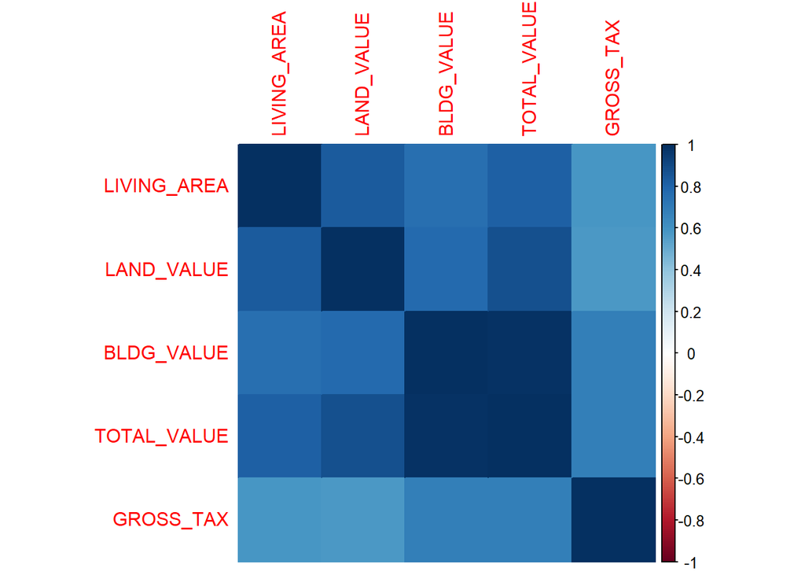

```r
library(corrplot)
corrplot(correlation_matrix, method = "color")
```

```r
model_data = fy2023_property_assessment_data %>%
  select(TOTAL_VALUE, LAND_SF, BED_RMS)
```

This analysis focuses on key property factors. The selected variables, Total Value, Land Area (LAND_SF), and Bedroom Count (BED_RMS), are crucial for real estate decisions. Examining these factors can aid businesses in strategic planning, investment decisions, and understanding the value drivers influencing property assessments and market trends.

```r
regression_model = lm(TOTAL_VALUE ~ LAND_SF + BED_RMS, data = model_data)
```

The regression model assesses the relationship between Total Property Value (TOTAL_VALUE) and predictors such as Land Area (LAND_SF) and the number of Bedrooms (BED_RMS). This analysis helps businesses understand how changes in land area and the number of bedrooms impact the overall assessed value of properties, aiding in strategic decision-making for real estate investments or valuations.

```r
summary(regression_model)
```

```
##
## Call:
## lm(formula = TOTAL_VALUE ~ LAND_SF + BED_RMS, data = model_data)
##
## Residuals:
##       Min        1Q    Median        3Q       Max
## -39445853   -378414   -210597     61860  29599464
##
## Coefficients:
##              Estimate Std. Error t value Pr(>|t|)
## (Intercept) 4.862e+05  9.531e+03   51.02   <2e-16 ***
## LAND_SF     2.804e+02  4.818e+00   58.21   <2e-16 ***
## BED_RMS     1.333e+05  3.776e+03   35.31   <2e-16 ***
## ---
## Signif. codes:  0 '***' 0.001 '**' 0.01 '*' 0.05 '.' 0.1 ' ' 1
##
## Residual standard error: 1147000 on 45070 degrees of freedom
##   (20462 observations deleted due to missingness)
## Multiple R-squared:  0.1481, Adjusted R-squared:  0.1481
## F-statistic:  3919 on 2 and 45070 DF,  p-value: < 2.2e-16
```